# 家中空气质量报告

编写者: Lina Ang

报告制作日期: 2025-04-15

## 简介

家庭编号: **PC036**

本报告概述了您家中的空气质量情况，聚焦于您家中**可吸入颗粒物 (PM<sub>2.5</sub>)** 的测量数据水平。您家中的 PM<sub>2.5</sub> 测量数据水平是根据每立方米空气中记录的细颗粒物（PM<sub>2.5</sub>）数量（颗粒数）计算得出的。我们将通过描述性统计数据和可视化图表展示相关发现。根据世界卫生组织（WHO）2021 年空气质量指南，PM<sub>2.5</sub> 的24小时平均浓度不应超过 15 微克/立方米。如需了解更多关于世卫组织空气质量指南的信息，请点击[链接](https://www.who.int/news-room/feature-stories/detail/what-are-the-who-air-quality-guidelines)。

本报告家中室内 PM<sub>2.5</sub> 空气质量的可视化图表中也包含了每小时平均的环境（户外）PM<sub>2.5</sub> 测量数据。历史环境 PM<sub>2.5</sub> 数据来自新加坡国家环境局（NEA）的 API，并可在 [data.gov.sg](https://data.gov.sg/datasets/d_e1058d6974c877257e32048ab128ad83/view#tag/default/GET/pm25) 获取。NEA 的 PM<sub>2.5</sub> 数据分为新加坡的五个区域：北部、南部、东部、西部和中部，每小时更新一次。我们选用了您家中所在区域的读数来代表户外空气质量。

请注意，您家中的 PM<sub>2.5</sub> 测量数据为未经校准的原始数据。

数据涵盖的采样时间为 **2025-03-25** 至 **2025-04-08**。

您家中的平均 PM<sub>2.5</sub> 测量数据**高于**世界卫生组织建议的 24 小时限值 15 微克/立方米，表明空气质量**较差**。

| Mean | PM<sub>2.5</sub> 测量数据 (微克/立方米) Min | PM<sub>2.5</sub> 测量数据 (微克/立方米) Max |
| --- | --- | --- |
| 16.17 | 3.62 | 37.62 |

Note:  
平均 PM<sub>2.5</sub> < 15 微克/立方米 = 空气质量良好; 平均 PM<sub>2.5</sub> ≥ 15 微克/立方米 = 空气质量较差。

## 每日平均 PM<sub>2.5</sub> 测量数据（家中 vs 户外）

本表展示了您家中每日（每日平均）PM<sub>2.5</sub> 测量数据的统计汇总。描述性统计包括 PM<sub>2.5</sub> 测量数据的平均值(mean)、最小值(min)和最大值(max)。

每日 PM<sub>2.5</sub> 测量数据统计(家中)

| Date (Day) | PM<sub>2.5</sub> 测量数据 (微克/立方米) Mean | PM<sub>2.5</sub> 测量数据 (微克/立方米) Min | PM<sub>2.5</sub> 测量数据 (微克/立方米) Max |
| --- | --- | --- | --- |
| 2025-03-25 (Tuesday) | 37.62 | 26.92 | 55.66 |
| 2025-03-26 (Wednesday) | 32.86 | 25.65 | 47.02 |
| 2025-03-27 (Thursday) | 27.08 | 20.32 | 35.81 |
| 2025-03-28 (Friday) | 14.12 | 7.19 | 25.26 |
| 2025-03-29 (Saturday) | 23.17 | 13.44 | 42.45 |
| 2025-03-30 (Sunday) | 18.75 | 8.83 | 27.14 |
| 2025-03-31 (Monday) | 20.82 | 8.19 | 41.92 |
| 2025-04-01 (Tuesday) | 15.35 | 11.07 | 20.58 |
| 2025-04-02 (Wednesday) | 6.34 | 0.36 | 13.85 |
| 2025-04-03 (Thursday) | 3.62 | 0.05 | 8.31 |
| 2025-04-04 (Friday) | 9.90 | 3.46 | 14.95 |
| 2025-04-05 (Saturday) | 11.29 | 5.81 | 23.36 |
| 2025-04-06 (Sunday) | 8.56 | 2.58 | 23.83 |
| 2025-04-07 (Monday) | 4.14 | 1.66 | 9.74 |
| 2025-04-08 (Tuesday) | 9.00 | 6.18 | 12.89 |

该图展示了您家中每日的平均 PM<sub>2.5</sub> 测量数据，并与新加坡国家环境局（NEA）提供的户外/环境 PM<sub>2.5</sub> 测量数据进行对比。图中标出了您家中 PM<sub>2.5</sub> 测量数据的三个最高峰值。

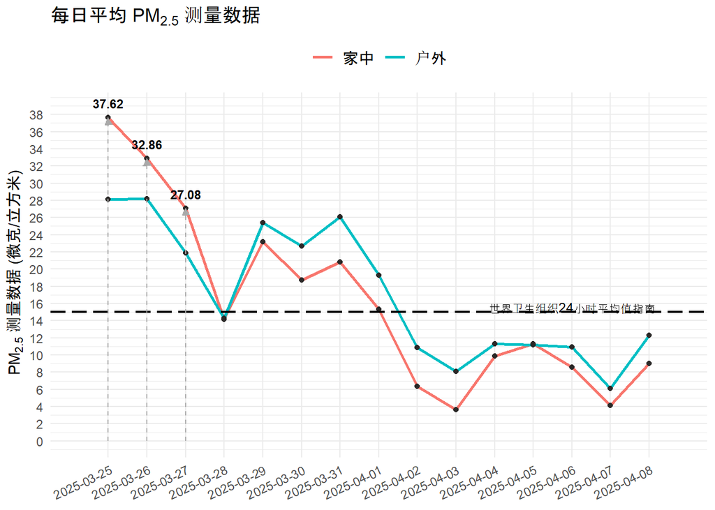

## 家中每小时平均 PM<sub>2.5</sub> 测量数据（工作日与周末对比）

本表展示了您家中 PM<sub>2.5</sub> 测量数据的统计汇总，按 Weekday 工作日（星期一至星期五）和 Weekend 周末（星期六与星期日）进行划分。描述性统计包括 PM<sub>2.5</sub> 测量数据的平均值(mean)、最小值(min)和最大值(max)。

家中 PM<sub>2.5</sub> 测量数据统计

| Day | PM<sub>2.5</sub> 测量数据 (微克/立方米) Mean | PM<sub>2.5</sub> 测量数据 (微克/立方米) Min | PM<sub>2.5</sub> 测量数据 (微克/立方米) Max |
| --- | --- | --- | --- |
| Weekend | 15.44 | 2.58 | 42.45 |
| Weekday | 15.58 | 0.05 | 55.66 |

该图展示了您家中在工作日（星期一至星期五）与周末（星期六与星期日）按小时划分的平均 PM<sub>2.5</sub> 测量数据水平。图中标出了三个您家中最高的PM<sub>2.5</sub>测量数据峰值。

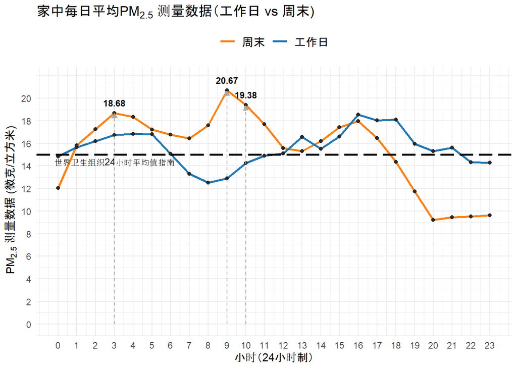

以下部分展示了您家中星期一至星期日的24小时平均 PM<sub>2.5</sub> 测量数据。

## 星期一

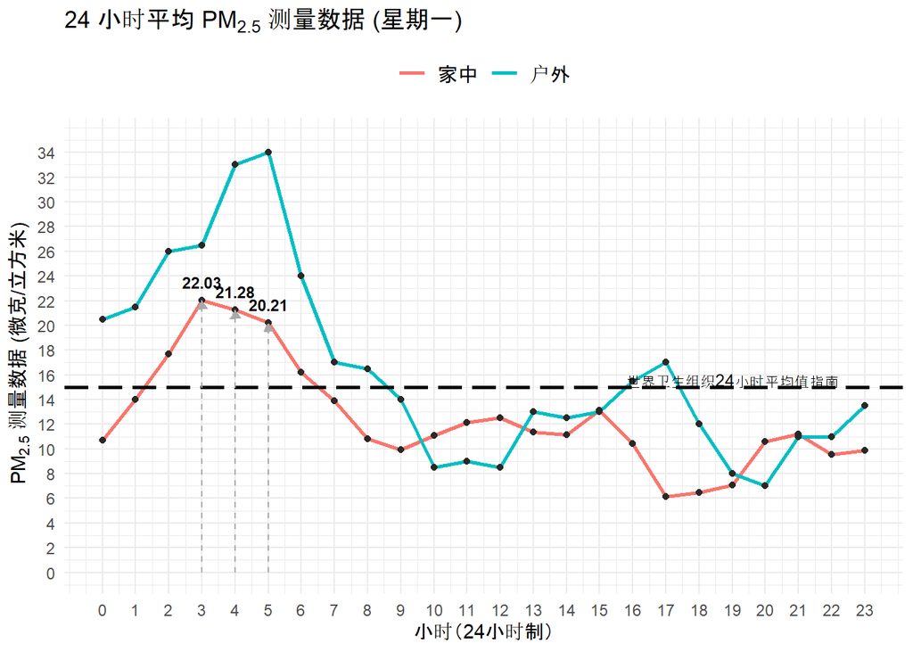

| Mean | PM<sub>2.5</sub> 测量数据 (微克/立方米) Min | PM<sub>2.5</sub> 测量数据 (微克/立方米) Max |
| --- | --- | --- |
| 12.48 | 6.12 | 22.03 |

## 星期二

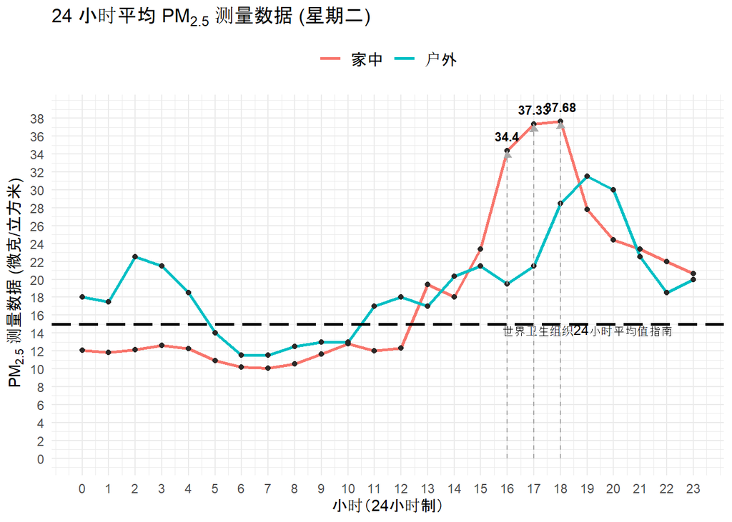

| Mean | PM<sub>2.5</sub> 测量数据 (微克/立方米) Min | PM<sub>2.5</sub> 测量数据 (微克/立方米) Max |
| --- | --- | --- |
| 18.33 | 10.06 | 37.68 |

## 星期三

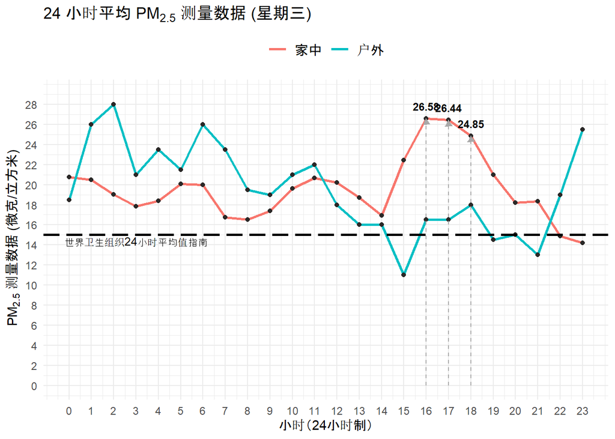

| Mean | PM<sub>2.5</sub> 测量数据 (微克/立方米) Min | PM<sub>2.5</sub> 测量数据 (微克/立方米) Max |
| --- | --- | --- |
| 19.6 | 14.22 | 26.58 |

## 星期四

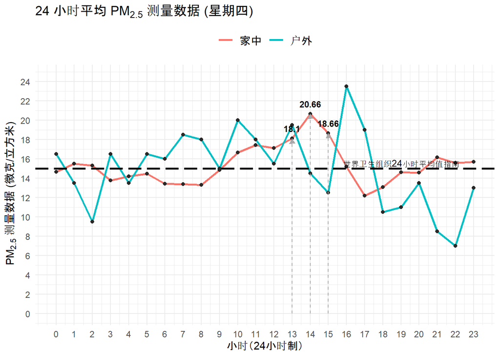

[output not shown]

## 星期五

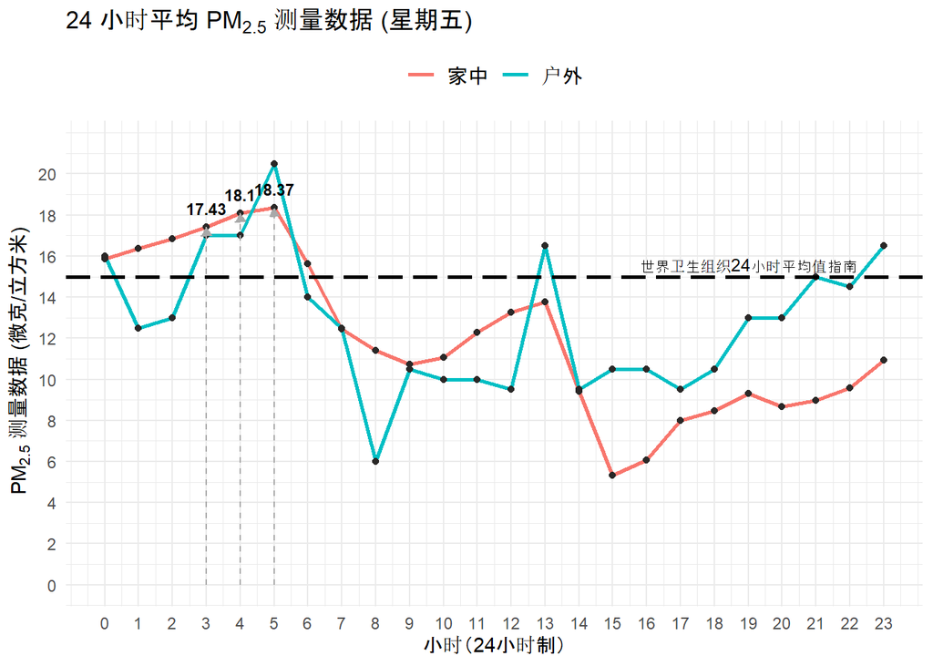

| Mean | PM<sub>2.5</sub> 测量数据 (微克/立方米) Min | PM<sub>2.5</sub> 测量数据 (微克/立方米) Max |
| --- | --- | --- |
| 12.01 | 5.32 | 18.37 |

## 星期六

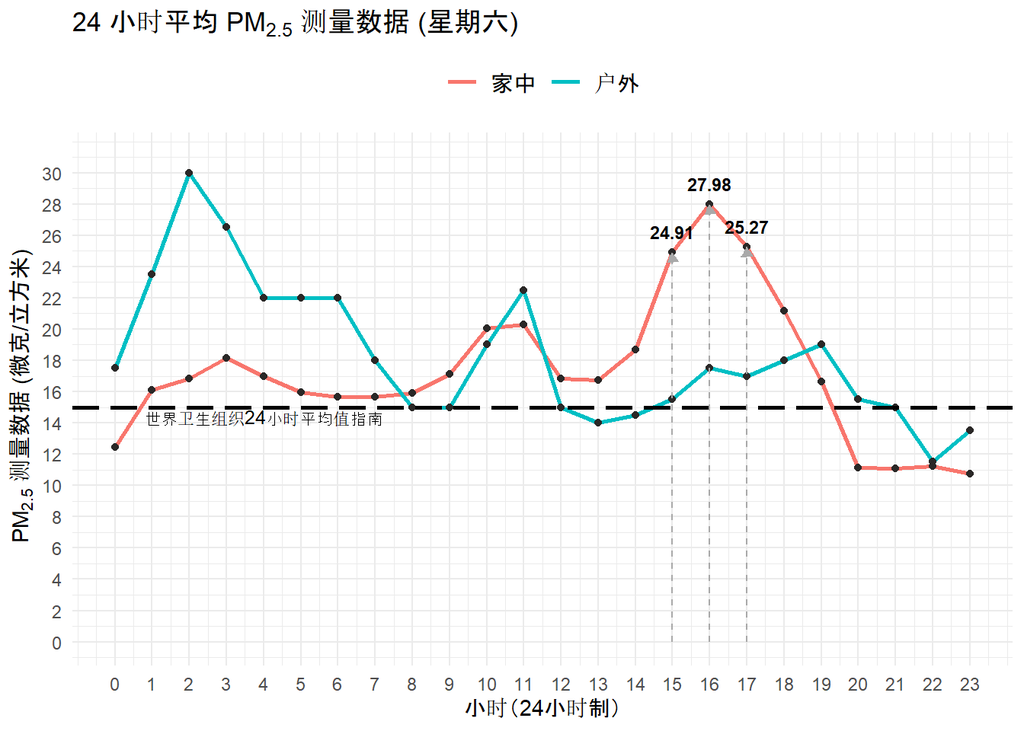

| Mean | PM<sub>2.5</sub> 测量数据 (微克/立方米) Min | PM<sub>2.5</sub> 测量数据 (微克/立方米) Max |
| --- | --- | --- |
| 17.23 | 10.72 | 27.98 |

## 星期日

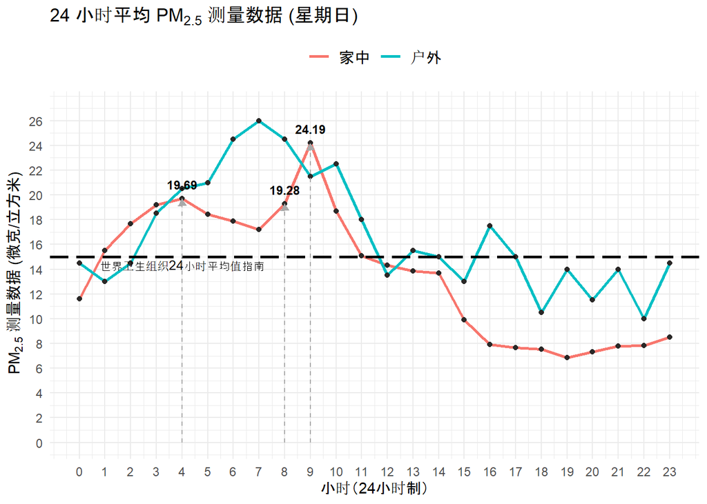

| Mean | PM<sub>2.5</sub> 测量数据 (微克/立方米) Min | PM<sub>2.5</sub> 测量数据 (微克/立方米) Max |
| --- | --- | --- |
| 13.65 | 6.83 | 24.19 |

## 联系信息

本报告中的数据和内容受版权保护，未经许可不得转载。 若需更多信息，请通过电子邮件联系我: ephanli@nus.edu.sg。

报告结束©